# Digital DNA:DNA hybridization (dDDH)

```r
library(tidyverse)
library(ggtext)
library(viridis)
```

## Set up paths

```r
#This will open the .Renviron file for the project. You need to add a DATA_PATH environment variable with the path to your data folder.
#usethis::edit_r_environ(scope = "project")

FOLDER_PATH <- Sys.getenv("DATA_PATH")
genomes_list_folder <- file.path(FOLDER_PATH, "genome_lists")
ggdc_folder <- file.path(FOLDER_PATH, "GGDC")
```

## Run dDDH

Pairwise comparisons were performed using the online Genome-to-Genome Distance Calculator ([GGDC](https://ggdc.dsmz.de/ggdc.php))(Meier-Kolthoff et al., 2013; Meier-Kolthoff et al., 2021) with default parameters (BLAST+(Camacho et al., 2009)) for the 28 proposed *Corynebacterium nasorum* genomes and for the 30 genomes in the *Corynebacterium tuberculostearicum* species complex.

Each file in the `ggdc_folder` contains the results for one query genome against all reference genomes. We read and combined these files into a single data frame with formula 2 results. We then join this data frame with the `StrainOrder` data frame to add the styled genome names and specify the order of the levels for plotting.

```r
combine_ggdc <- function(data_path, StrainOrder_path) {

  # List all matching files
  file_list <- list.files(path = data_path, pattern = "^ggdc_results_.*\\.csv$", full.names = TRUE)

  # Function to read each file
  read_ggdc <- function(file) {
    # Read the data skipping the second header row
    df <- read_csv(file, skip = 1, show_col_types = FALSE)

    # Make column names unique
    names(df) <- make.names(names(df), unique = TRUE)

    return(df)
  }

  # Read and bind all files
  all_ggdc_results <- map_dfr(file_list, read_ggdc)

  # Select desired columns for Formula 2
  ggdc_formula2 <- all_ggdc_results %>%
    select(
      Query.genome,
      Reference.genome,
      `DDH...7`,
      `Model.C.I....8`,
      `Distance...9`,
      `Prob..DDH....70....10`
    )

  # Rename them to cleaner names
  ggdc_formula2 <- ggdc_formula2 %>%
    rename(
      Genome1 = Query.genome,
      Genome2 = Reference.genome,
      DDH = `DDH...7`,
      CI = `Model.C.I....8`,
      Distance = `Distance...9`,
      Prob_DDH_70 = `Prob..DDH....70....10`
    )

  # Read the strain order from a CSV file and specify the order of the levels
  StrainOrder <- read_csv(StrainOrder_path)

  # Join the ggdc_formula2 and StrainOrder data frames based on Genome1
  ggdc_formula2 <- left_join(ggdc_formula2, StrainOrder, by = c("Genome1" = "Genome")) %>%
    rename(styled_Genome1 = styled_Genome)

  # Convert the 'styled_Genome1' and 'Genome1' columns to a factor and specify the order of the levels
  ggdc_formula2$styled_Genome1 <- factor(ggdc_formula2$styled_Genome1, levels = StrainOrder$styled_Genome)
  ggdc_formula2$Genome1 <- factor(ggdc_formula2$Genome1, levels = StrainOrder$Genome)

  # Join the ggdc_formula2 and StrainOrder data frames based on Genome2
  ggdc_formula2 <- left_join(ggdc_formula2, StrainOrder, by = c("Genome2" = "Genome")) %>%
    rename(styled_Genome2 = styled_Genome)

  # Convert the 'styled_Genome2' and 'Genome2' columns to a factor and specify the order of the levels
  ggdc_formula2$styled_Genome2 <- factor(ggdc_formula2$styled_Genome2, levels = StrainOrder$styled_Genome)
  ggdc_formula2$Genome2 <- factor(ggdc_formula2$Genome2, levels = StrainOrder$Genome)

  return(ggdc_formula2)
}
```

Generate the data frames for the two datasets.

```r
dDDH_28 <- combine_ggdc(file.path(ggdc_folder, "NovCor_28_Cna"),
  file.path(genomes_list_folder, "ANI_PlotOrder_28_Cna_styled.csv"))
dDDH_30 <- combine_ggdc(file.path(ggdc_folder, "NovCor_30_CtuComplex"),
  file.path(genomes_list_folder, "ANI_PlotOrder_30_CtuComplex_styled.csv"))
```

## Plots

```r
plot_DDH <- function(dDDH) {
  pdDDH <- ggplot(dDDH, aes(x = styled_Genome1, y = styled_Genome2, fill = DDH)) +
    geom_tile(width = 1.0, height = 1.0) +
    geom_text(aes(label = DDH), size = 3, colour = "black") +
    scale_fill_viridis(option = "A", begin = 0.6) +
    scale_y_discrete(position = "right") +
    labs(x = NULL, y = NULL, title = NULL) +
    theme_bw() +
    theme(axis.text.x = element_markdown(angle = 45, vjust = 1, hjust = 1, colour = "black", face = "bold"),
          axis.text.y = element_markdown(colour = "black", face = "bold"),
          panel.border = element_blank(),
          panel.grid.major = element_blank(),
          panel.grid.minor = element_blank(),
          axis.ticks = element_blank(),
          plot.margin = margin(0, 0.25, 0.25, 1, "cm"),
          legend.position = c(1.12, -0.12),
          legend.direction = "horizontal",
          legend.justification = c(1, 0)) +
    guides(fill = guide_colourbar(title = "dDDH Formula 2", title.position = "top", title.hjust = 0.5, barwidth = 6))
  return(pdDDH)
}
```

Generate the plots for the two datasets.

```r
pdDDH_28 <- plot_DDH(dDDH_28)
pdDDH_30 <- plot_DDH(dDDH_30)
```

Function to add colored rectangles to the plot, which we will use to highlight the different species groups in the *C. tuberculostearicum* species complex.

```r
add_rectangles_to_heatmap <- function(plot, levels, top, bottom, color) {
  top_pos <- which(levels == top)
  bottom_pos <- which(levels == bottom)

  p_with_rect <- plot +
    geom_rect(
      aes(xmin = top_pos + 0.5,
          xmax = bottom_pos - 0.5,
          ymin = top_pos + 0.5,
          ymax = bottom_pos - 0.5),
      fill = NA,
      color = color,
      size = 1
    )

  return(p_with_rect)
}
```

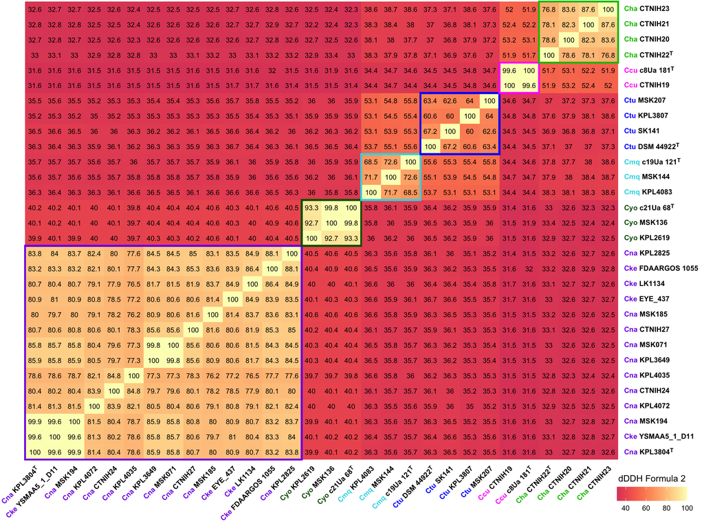

```r
genome_levels <- levels(pdDDH_30$data$Genome1)
pdDDH_30 <- add_rectangles_to_heatmap(pdDDH_30, genome_levels, "Cna_KPL2825", "Cna_KPL3804", "#8200E7")
pdDDH_30 <- add_rectangles_to_heatmap(pdDDH_30, genome_levels, "Cyo_c21Ua_68", "Cyo_KPL2619", "#0A6003")
pdDDH_30 <- add_rectangles_to_heatmap(pdDDH_30, genome_levels, "Cmq_c19Ua_121", "Cmq_KPL4083", "#39D9E5")
pdDDH_30 <- add_rectangles_to_heatmap(pdDDH_30, genome_levels, "Ctu_MSK207", "Ctu_DSM_44922", "#002BFF")
pdDDH_30 <- add_rectangles_to_heatmap(pdDDH_30, genome_levels, "Ccu_c8Ua_181", "Ccu_CTNIH19", "#FF00FF")
pdDDH_30 <- add_rectangles_to_heatmap(pdDDH_30, genome_levels, "Cha_CTNIH23", "Cha_CTNIH22", "#0ABF00")
pdDDH_30
```

## Outputs

```r
write_csv(dDDH_28, file.path(ggdc_folder, "ggdc_formula2_NovCor_28_Cna.csv"))
write_csv(dDDH_30, file.path(ggdc_folder, "ggdc_formula2_NovCor_30_CtuComplex.csv"))

ggsave(file.path(ggdc_folder, "NovCor_dDDH_NovCor_28_Cna.png"), plot = pdDDH_28, width = 12, height = 9, dpi = 600)
ggsave(file.path(ggdc_folder, "NovCor_dDDH_NovCor_30_CtuComplex.png"), plot = pdDDH_30, width = 12, height = 9, dpi = 600)

saveRDS(pdDDH_28, file = file.path(ggdc_folder, "NovCor_dDDH_NovCor_28_Cna.rds"))
saveRDS(pdDDH_30, file = file.path(ggdc_folder, "NovCor_dDDH_NovCor_30_CtuComplex.rds"))
```

The results based on the recommended GGDC Formula 2 are reported in the manuscript in the following tables and figures:

- **dDDH_28:** Table S1, for each genome proposed to belong to *C. nasorum* against the type strain (KPL3804).
- **dDDH_30:** Table S2, full pairwise comparisons for all included genomes against each other; and Figure 2B, ordered to map the ANI results (Fig 2A)

**Camacho, C., Coulouris, G., Avagyan, V., Ma, N., Papadopoulos, J., Bealer, K. and Madden, T. L.** (2009). [BLAST+: architecture and applications](https://doi.org/10.1186/1471-2105-10-421). *BMC Bioinformatics* 10,.

**Meier-Kolthoff, J. P., Auch, A. F., Klenk, H.-P. and Göker, M.** (2013). [Genome sequence-based species delimitation with confidence intervals and improved distance functions](https://doi.org/10.1186/1471-2105-14-60). *BMC Bioinformatics* 14,.

**Meier-Kolthoff, J. P., Carbasse, J. S., Peinado-Olarte, R. L. and Göker, M.** (2021). [TYGS and LPSN: a database tandem for fast and reliable genome-based classification and nomenclature of prokaryotes](https://doi.org/10.1093/nar/gkab902). *Nucleic Acids Research* 50, D801–D807.